# Data Analysis 3 - Pattern Discovery and Regression Analysis 2017/2018 Fall

Peter Paziczki

Imre Boda

Balazs Zankay

2017 november 28

# DA3 Assignment #2

## Problem2.1

### Download cross-country data on life expectancy and GDP per capita. - “GDP per capita, PPP (constant)” and “Life expectancy at birth (total)”

We have downloaded both the above mentioned indicators for 2014, storing them in two separate csv files, GDP_per_capita_2014-Data.csv and Life_expectancy_at_birth_2014-Data.csv.

### Q1. 1. Delete unnecessary columns and save a csv file with three columns only: country name, life expectancy and GDP per capita. Keep countries with non-missing values for life expectancy and GDP per capita. Document what you do.

#### Data preparation and Cleaning

We have loaded both csv files and merged them with inner join. By using this special command we could make sure that relevant columns (Life expectancy and GDP) from the two tables were merged by matching the country name column, so the right values have been paired. The countries with missing life expectancy and GDP values have been dropped. We have 225 entries of the 264 left to analyze. Other unnecessary columns have also been dropped, such as Series Name, Series Code, Country Code. We have renamed the remaining columns as *country*, *life* and *GDP*, so it will be easier to type and use them. Life expectancy at birth is measure of how long people people live on average in a specific country. GDP per capita stands for gross domestic product at purchasing power parity of a specific country, both at 2014 in our case. Finally we have divided GDP per capita by 1000 and took the log of it because GPD per capita makes more sense in relative than in absolute terms, we will investigate it further in the next exercise.

We have downloaded a csv file containing the list of 209 countries in the world as of now. There were many entries in our data set that were not about countries but some aggregations, so they were dropped. We have aggregated lines in the data, that we have to remove as we only care about countries in the analysis. We do this cleaning in two steps: first we check entries where the “country” is not inlcuded in the list of downloaded countries. Then we manually checked all of them, and collected those that are really not countries. (In the previous step some get classified as “non country” due to different writing in Data Bank and in the downloaded country list csv file). Once we had this collection of real non-countries, we removed all from the Data.

The 46 entries have been dropped because of being marked as non-countries. After data cleaning we have 179 countries to investigate.

Please find summary statistics of life variable below:

| Min. | 1st Qu. | Median | Mean | 3rd Qu. | Max. |
| --- | --- | --- | --- | --- | --- |
| 50.59 | 65.9 | 72.97 | 71.34 | 76.88 | 83.98 |

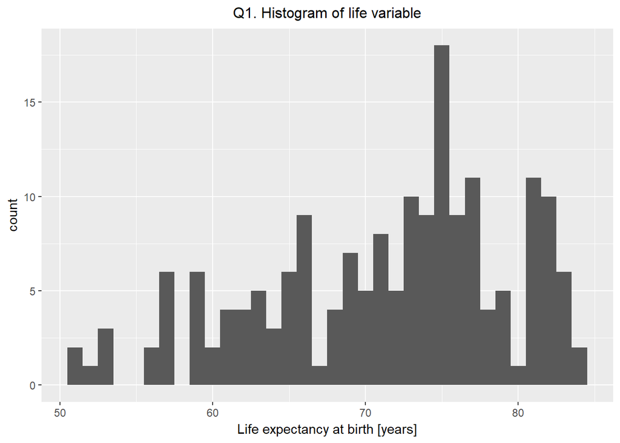

|  | life | GDP | logGDP |
| --- | --- | --- | --- |
| **Central African Republic** | 50.59 | 0.6018 | -0.5079 |
| **Hong Kong SAR, China** | 83.98 | 52.7 | 3.965 |

Life expactancy is the highest in Hong Kong SAR, China, and the lowest in the Central African Republic, 83.98 and 50.59 respectively. The difference between the minimum and maximum values is quite large. Mean is close to the median, but life expectancy variable does not have a symmetric distribution, it rather seems to be skewed to the left.

Please find summary statistics of GDP per capita variable below:

| Min. | 1st Qu. | Median | Mean | 3rd Qu. | Max. |
| --- | --- | --- | --- | --- | --- |
| 0.6018 | 3.644 | 10.75 | 18.12 | 24.61 | 130.8 |

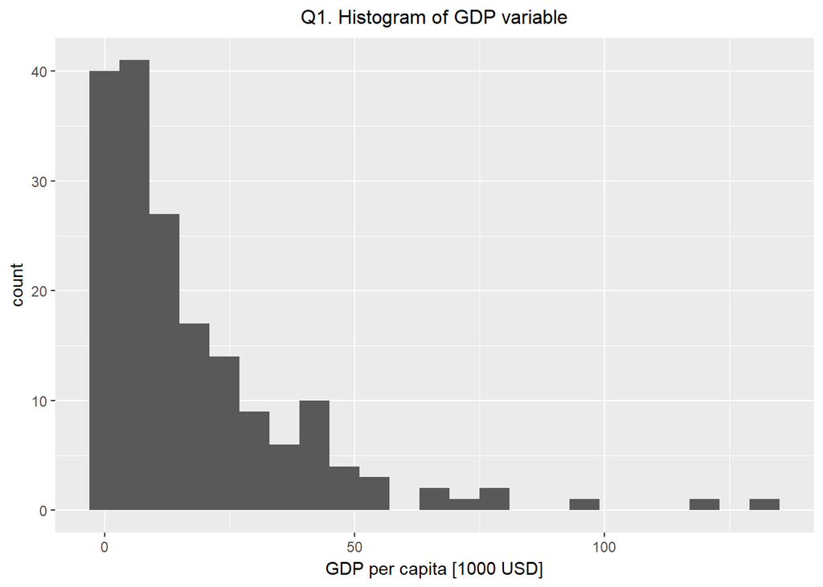

Countries with minimuma and maximum GDP are the followings:

|  | life | GDP | logGDP |
| --- | --- | --- | --- |
| **Central African Republic** | 50.59 | 0.6018 | -0.5079 |
| **Macao SAR, China** | 83.43 | 130.8 | 4.873 |

GDP follows a log normal like distribution with a long right tail, it is tipically a clear sign that we are better to take the logarithm of the variable. GDP is the highest in Macao SAR, China, and the lowest in the Central African Republic, 130.76 and 0.6 respectively. In this case the difference between the minimum and maximum value is very large.

Please find summary statistics of logGDP variable below:

| Min. | 1st Qu. | Median | Mean | 3rd Qu. | Max. |
| --- | --- | --- | --- | --- | --- |
| -0.5079 | 1.293 | 2.375 | 2.262 | 3.203 | 4.873 |

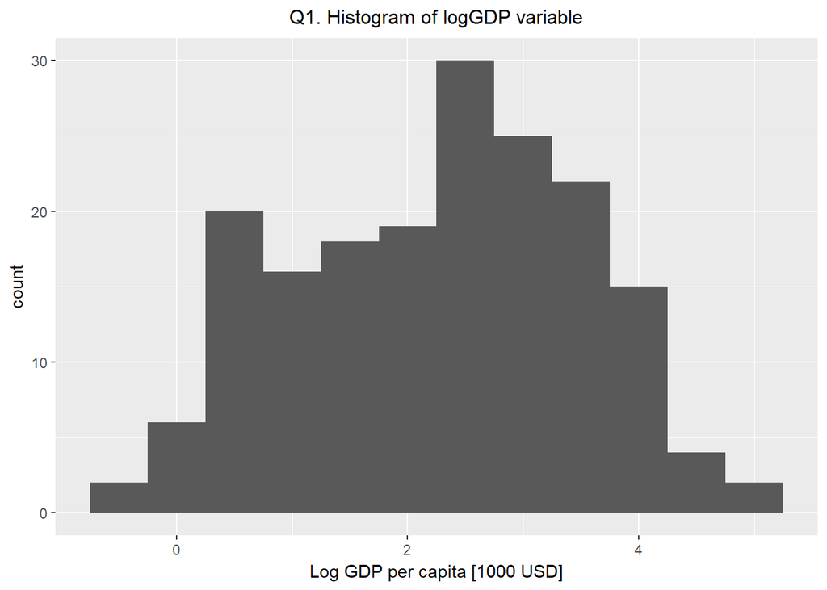

The histogram of logGDP per capita has a more symmetric distribution then the GDP per capita variable. The spread is also big in this case.

### Q2. Estimate a lowess regression of life expectancy on ln gdp per capita. Estimate a linear regression of life expectancy on GDP per capita that best captures the nonlinearity you found (life expectancy on a piecewise linear spline or a polynomial in the explanatory variable). Argue for your choice. Report the coefficient estimates as well as their confidence interval, interpret and visualize the results.

In the following sections we go deeper in understanding our data.

First, let’s have a look at the scatterplot with GDP per capita on the x axis and life expectancy at birth on the y axis.

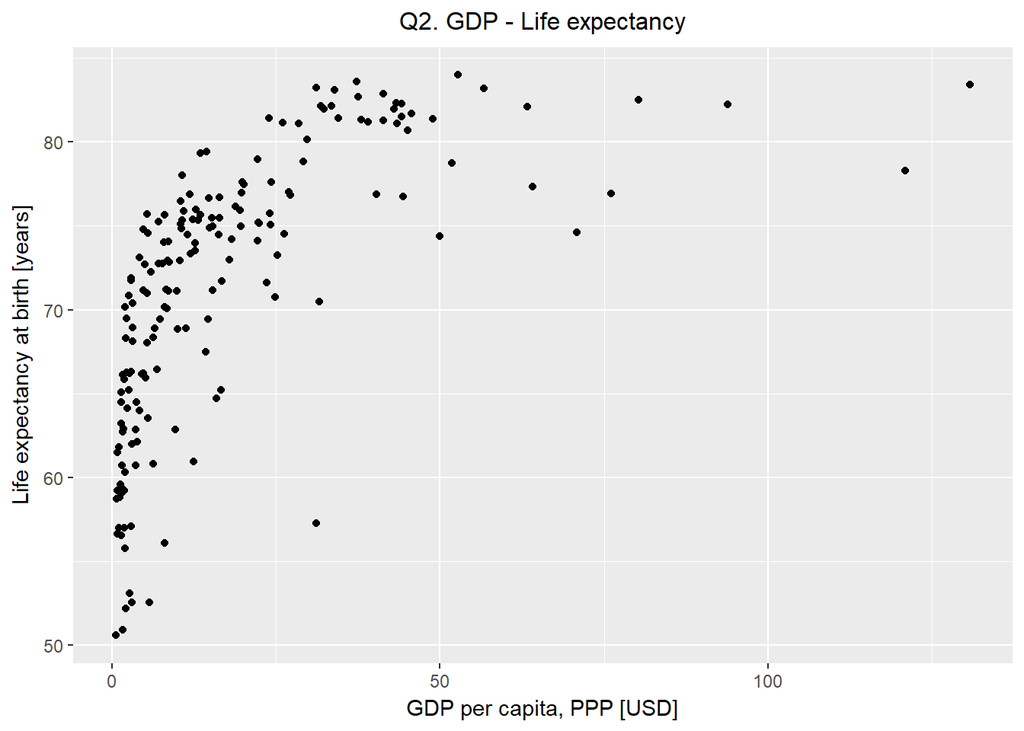

Many countries have a low level of GDP per capita, thus there are many observations close to the y axis. As we stated above, GDP per capita is strongly skewed to the right, having logGDP on the x axis might give a fit.

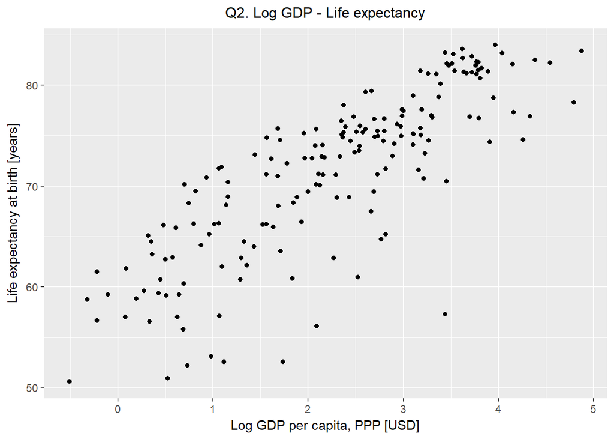

We took the log of GDP per capita, as we are interested in relative % changes instead of absolute terms. Lowess produces a smooth curve, that allows us to capture non-linear patterns. (The con of lowess is that it does not provide a formula to describe the relationship between life expectancy and GDP. What lowess does is that it provides an expected y value for every x values and for x values in-between resulting in a graph that we can use in qualitative analysis. In this particular case we have log GDP per capita on the x axis and life expectancy on the y axis.

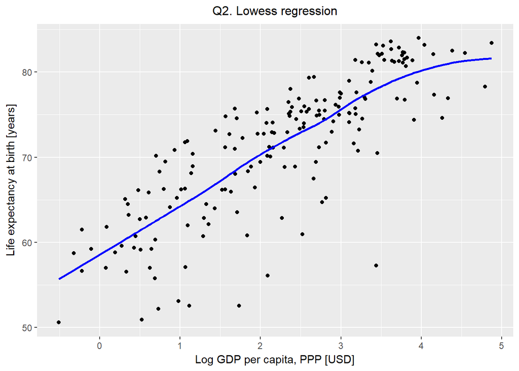

```
## Call:
## loess(formula = life ~ logGDP, data = Data)
##
## Number of Observations: 179
## Equivalent Number of Parameters: 4.8
## Residual Standard Error: 4.738
## Trace of smoother matrix: 5.25  (exact)
##
## Control settings:
##   span     :  0.75
##   degree   :  2
##   family   :  gaussian
##   surface  :  interpolate      cell = 0.2
##   normalize:  TRUE
##  parametric:  FALSE
## drop.square:  FALSE
```

We can see that the graph has a positive slope in general. At the right end of the curve it gets a little flatter, but remains still positive. So we can assumte that there is some sort of positive correlation between these two variables. A possible interpretation at this point can be that there is a general positive relationship between GDP per capita and life expectancy. The higher the GDP per capita is in a country, the longer the life expectancy is on average.

#### Level - Log Linear Regression

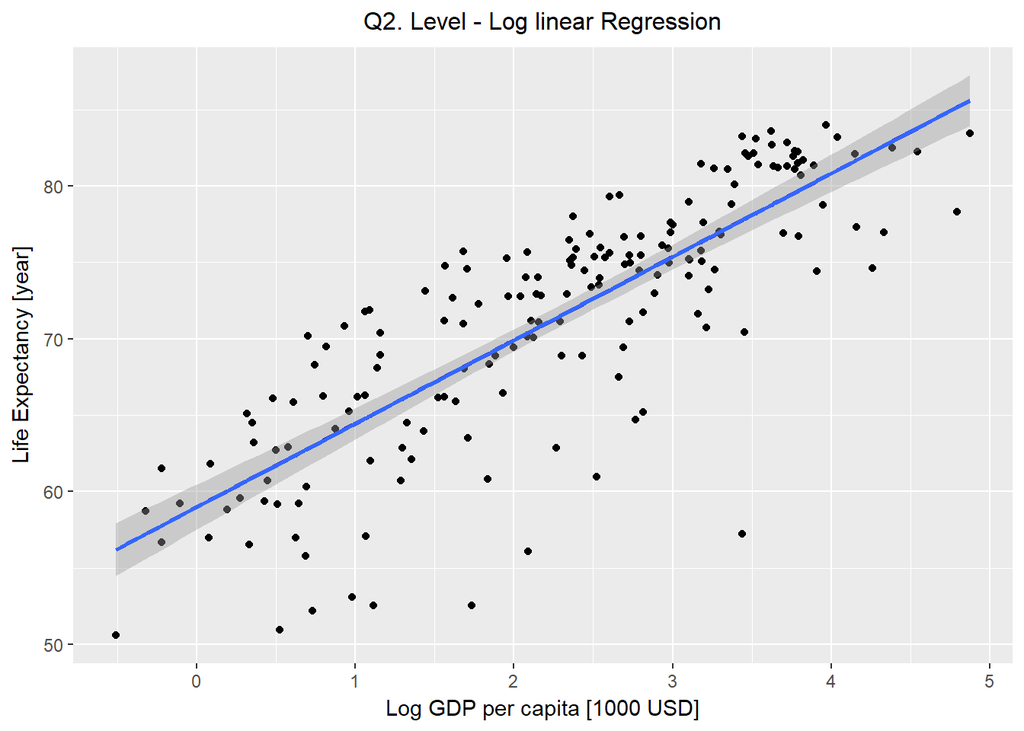

```
##
## Call:
## lm(formula = life ~ logGDP, data = Data)
##
## Residuals:
##     Min      1Q  Median      3Q     Max
## -20.514  -2.291   1.053   3.080   7.533
##
## Coefficients:
##             Estimate Std. Error t value Pr(>|t|)
## (Intercept)  58.9839     0.7483   78.83   <2e-16 ***
## logGDP        5.4607     0.2914   18.74   <2e-16 ***
## ---
## Signif. codes:  0 '***' 0.001 '**' 0.01 '*' 0.05 '.' 0.1 ' ' 1
##
## Residual standard error: 4.738 on 177 degrees of freedom
## Multiple R-squared:  0.6648, Adjusted R-squared:  0.663
## F-statistic: 351.1 on 1 and 177 DF,  p-value: < 2.2e-16
```

We seem to have rather small residual errors and pretty good R-squared, 66.5%, confirming the relationship between logGDP and Life Expectancy. The intercept estimate is 58.98, which is hard to interpret in real life for practical reasons, it means that in a country with 0 logGDP the life expectancy at birth would be approx. 59 years on average. The slope estimate is 5.46, which means that life expectancy is 0.546 years higher on average in countries with 10% higher GDP per capita. The slope estimate is significant at 0.1%, with other words, life expectancy and log GDP per capita are correlated at a 99.9%.

Equatorial Guinea has the greatest negative residual, the life expectancy is 20.51 lower that one could expect based on the regression. The next two countries with greatest negative residuals are Nigeria and Swaziland, -15.9 and -14.3 years respectively. The highest positive residuals are Vietnam, Solomin Islands and Nicaragua, the residuals are over 7 years, meaning that people live more than 7 years longer on average, as one could expect based on the GDP per capita.

The residuals of the seven countries with highest GDP per capita are all negative, which is quite unexpected. This is something that we are going to consider when creating piecewise linear splines.

#### Log - Log regression

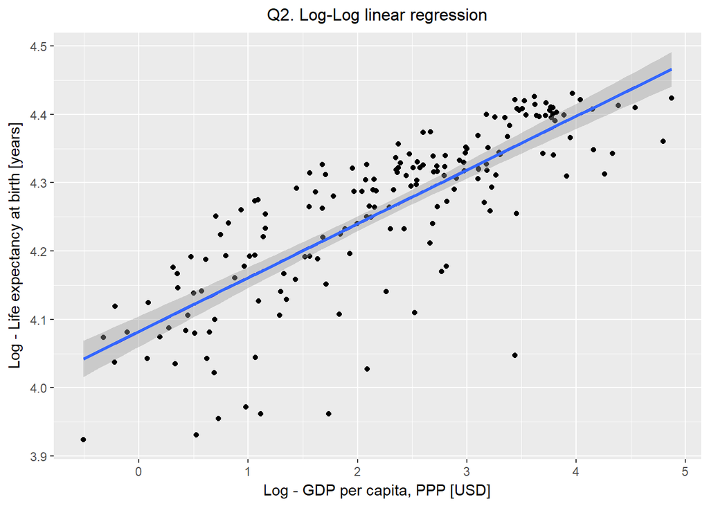

```
##
## Call:
## lm(formula = log(life) ~ logGDP, data = Data)
##
## Residuals:
##      Min       1Q   Median       3Q      Max
## -0.30578 -0.03142  0.01683  0.04757  0.11309
##
## Coefficients:
##             Estimate Std. Error t value Pr(>|t|)
## (Intercept) 4.082303   0.011333  360.21   <2e-16 ***
## logGDP      0.078776   0.004414   17.85   <2e-16 ***
## ---
## Signif. codes:  0 '***' 0.001 '**' 0.01 '*' 0.05 '.' 0.1 ' ' 1
##
## Residual standard error: 0.07176 on 177 degrees of freedom
## Multiple R-squared:  0.6428, Adjusted R-squared:  0.6408
## F-statistic: 318.5 on 1 and 177 DF,  p-value: < 2.2e-16
```

R-squared is slightly lower than in the previous case, but it is not significant at all. Also, this regression is more difficult to interpret. It can be interpreted as life expectency is 0.078% higher on average for observations with 1% higher GDP per capita.

#### Lev - Lev regression

Though the scatterplots above suggested that the level - level linear correlation probaly is not the best model, just for the sake of completeness let’s see a level-level linear regression model.

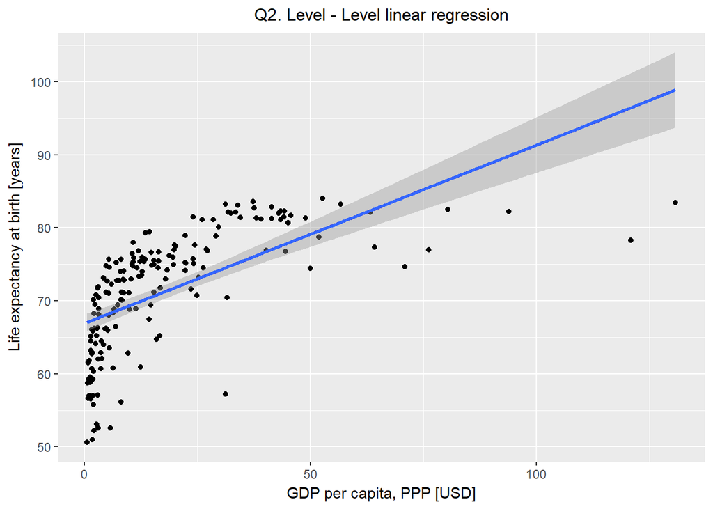

```
##
## Call:
## lm(formula = life ~ GDP, data = Data)
##
## Residuals:
##     Min      1Q  Median      3Q     Max
## -18.139  -4.113   2.076   4.750   9.121
##
## Coefficients:
##             Estimate Std. Error t value Pr(>|t|)
## (Intercept) 66.90863    0.63060  106.10   <2e-16 ***
## GDP          0.24437    0.02281   10.71   <2e-16 ***
## ---
## Signif. codes:  0 '***' 0.001 '**' 0.01 '*' 0.05 '.' 0.1 ' ' 1
##
## Residual standard error: 6.374 on 177 degrees of freedom
## Multiple R-squared:  0.3935, Adjusted R-squared:   0.39
## F-statistic: 114.8 on 1 and 177 DF,  p-value: < 2.2e-16
```

Both R-squared and the plot confirms our assumption that there are much better models that the simple level - level linear regression. This plot could obviously not capture the relationship as good as the previous ones.

#### Level - Level Quadratic regression

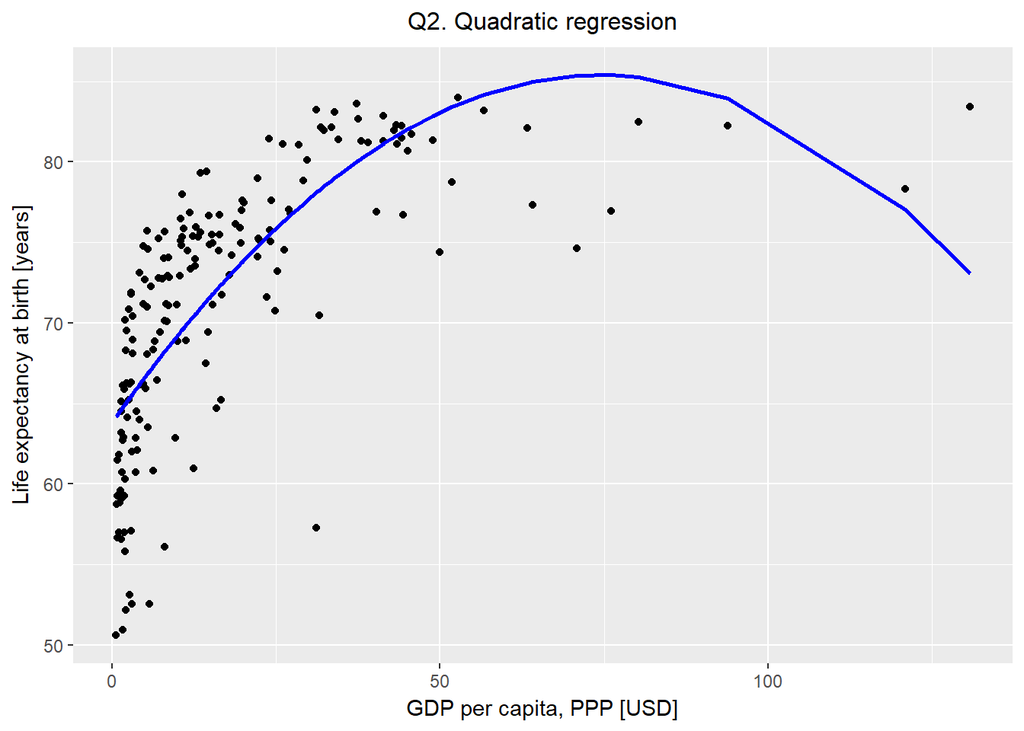

```
##
## Call:
## lm(formula = life ~ GDP + GDP_sq, data = Data)
##
## Residuals:
##      Min       1Q   Median       3Q      Max
## -20.8467  -2.7902   0.8156   3.8851  10.3418
##
## Coefficients:
##               Estimate Std. Error t value Pr(>|t|)
## (Intercept) 63.8129155  0.6500948  98.159  < 2e-16 ***
## GDP          0.5793830  0.0444351  13.039  < 2e-16 ***
## GDP_sq      -0.0038887  0.0004644  -8.374 1.69e-14 ***
## ---
## Signif. codes:  0 '***' 0.001 '**' 0.01 '*' 0.05 '.' 0.1 ' ' 1
##
## Residual standard error: 5.405 on 176 degrees of freedom
## Multiple R-squared:  0.5663, Adjusted R-squared:  0.5613
## F-statistic: 114.9 on 2 and 176 DF,  p-value: < 2.2e-16
```

R-squared is lower and residual error is higher than before, indicating that it might not be as good model as the previous one. Frankly, probably there is nothing to justify that life expectancy would peek at 74 kUSD GDP per capita, and very rich countries would suffer. The reasonably small error rate to this model is likely attributable to the fact that we have very few very rich countries (hence, small number of observations on this end.)

#### Level - Log Quadratic regression

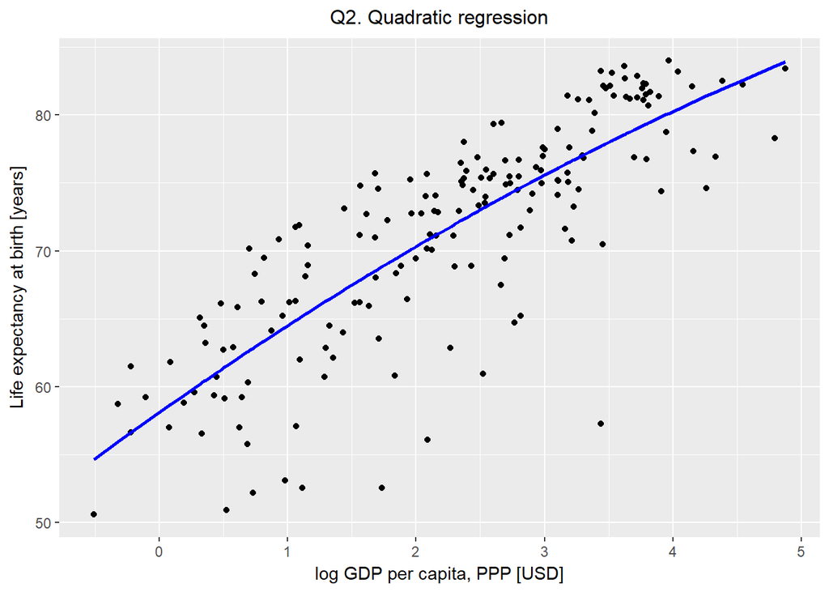

```
##
## Call:
## lm(formula = life ~ logGDP + logGDP_sq, data = Data)
##
## Residuals:
##      Min       1Q   Median       3Q      Max
## -20.4580  -2.1640   0.9584   2.9793   7.4996
##
## Coefficients:
##             Estimate Std. Error t value Pr(>|t|)
## (Intercept)  58.1073     1.0180  57.082  < 2e-16 ***
## logGDP        6.6754     1.0015   6.665 3.27e-10 ***
## logGDP_sq    -0.2838     0.2239  -1.268    0.207
## ---
## Signif. codes:  0 '***' 0.001 '**' 0.01 '*' 0.05 '.' 0.1 ' ' 1
##
## Residual standard error: 4.73 on 176 degrees of freedom
## Multiple R-squared:  0.6679, Adjusted R-squared:  0.6641
## F-statistic:   177 on 2 and 176 DF,  p-value: < 2.2e-16
```

#### Level - Level Cubic Regression

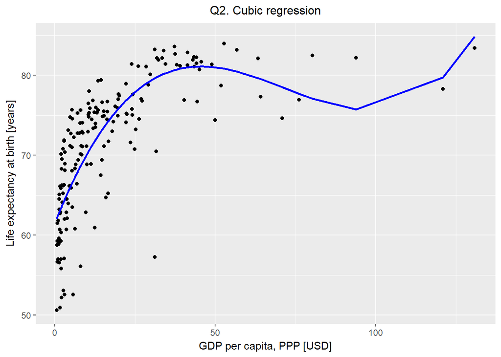

```
##
## Call:
## lm(formula = life ~ GDP + GDP_sq + GDP_cu, data = Data)
##
## Residuals:
##      Min       1Q   Median       3Q      Max
## -22.3987  -2.3871   0.8794   3.0844   9.2052
##
## Coefficients:
##               Estimate Std. Error t value Pr(>|t|)
## (Intercept)  6.147e+01  7.283e-01  84.399  < 2e-16 ***
## GDP          1.021e+00  8.807e-02  11.592  < 2e-16 ***
## GDP_sq      -1.642e-02  2.254e-03  -7.286 1.05e-11 ***
## GDP_cu       7.632e-05  1.348e-05   5.663 5.99e-08 ***
## ---
## Signif. codes:  0 '***' 0.001 '**' 0.01 '*' 0.05 '.' 0.1 ' ' 1
##
## Residual standard error: 4.983 on 175 degrees of freedom
## Multiple R-squared:  0.6335, Adjusted R-squared:  0.6272
## F-statistic: 100.8 on 3 and 175 DF,  p-value: < 2.2e-16
```

#### Level - Log Cubic Regression

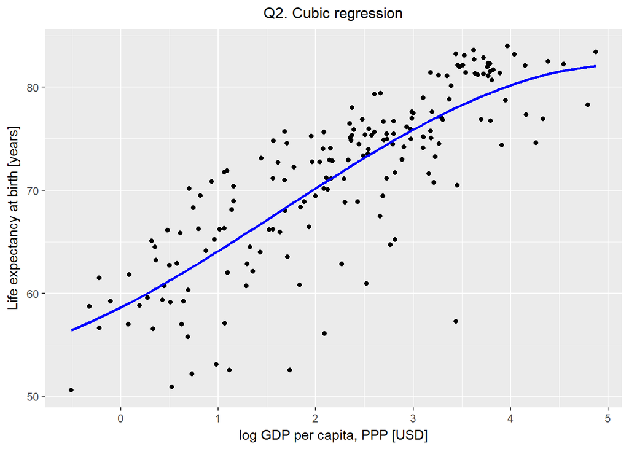

```
##
## Call:
## lm(formula = life ~ logGDP + logGDP_sq + logGDP_cu, data = Data)
##
## Residuals:
##     Min      1Q  Median      3Q     Max
## -20.750  -2.163   1.100   2.929   7.788
##
## Coefficients:
##             Estimate Std. Error t value Pr(>|t|)
## (Intercept)  58.6389     1.1323  51.789   <2e-16 ***
## logGDP        4.8262     1.9966   2.417   0.0167 *
## logGDP_sq     0.8054     1.0418   0.773   0.4405
## logGDP_cu    -0.1662     0.1553  -1.070   0.2859
## ---
## Signif. codes:  0 '***' 0.001 '**' 0.01 '*' 0.05 '.' 0.1 ' ' 1
##
## Residual standard error: 4.728 on 175 degrees of freedom
## Multiple R-squared:   0.67,  Adjusted R-squared:  0.6644
## F-statistic: 118.5 on 3 and 175 DF,  p-value: < 2.2e-16
```

#### Piecewise Linear Spline

In the lowess diagram we have seen that the slope is changing at about x = 4. This is confirmed by our finding at the log-level regression where we uncovered that the seven countries with highest GDP per capita all have negative residuals (i.e. in all these super-rich countries life expectancy was below the linear regression line). We selected the knot accordingly and build the PLS model.

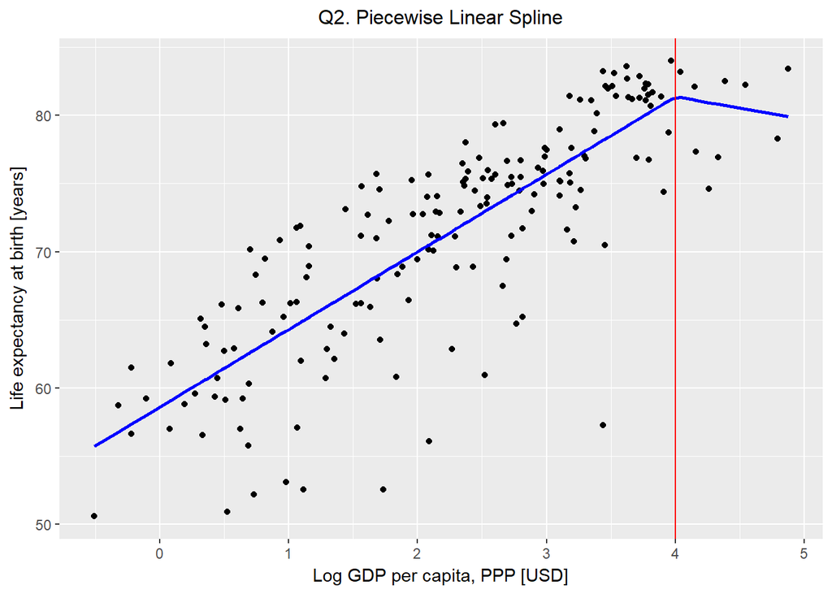

```
##
## Call:
## lm(formula = life ~ lspline(logGDP, knots), data = Data)
##
## Residuals:
##     Min      1Q  Median      3Q     Max
## -20.928  -2.191   1.008   3.038   7.548
##
## Coefficients:
##                         Estimate Std. Error t value Pr(>|t|)
## (Intercept)              58.6128     0.7629  76.826   <2e-16 ***
## lspline(logGDP, knots)1   5.6889     0.3092  18.399   <2e-16 ***
## lspline(logGDP, knots)2  -1.6650     3.4621  -0.481    0.631
## ---
## Signif. codes:  0 '***' 0.001 '**' 0.01 '*' 0.05 '.' 0.1 ' ' 1
##
## Residual standard error: 4.695 on 176 degrees of freedom
## Multiple R-squared:  0.6728, Adjusted R-squared:  0.6691
## F-statistic: 180.9 on 2 and 176 DF,  p-value: < 2.2e-16
```

#### Choosing the best model and evaluating it

| V1 | V2 |
| --- | --- |
| Level - Log : | 0.6648 |
| Log - Log : | 0.6428 |
| Level - Level: | 0.3935 |
| Quadratic Level - Level : | 0.5663 |
| Quadratic Level -Log | 0.6679 |
| Cubic Level - Level : | 0.6335 |
| Cubic Level - Log : | 0.67 |
| PLS (spline) : | 0.6728 |

Confidence interval (CI) of the predicted value tells us where to expect average y given the value of x in the population represented by the data. In the below two charts we put up the 95% mean and confidence intervales for lowess - linear (level - log) and lowess - PLS regressions. The reason why we selected lowess as a comparison base is that it is supposed to be the closest fit.

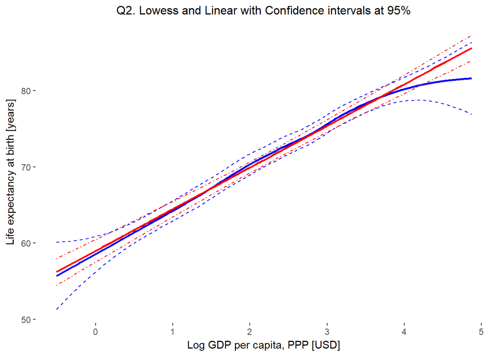

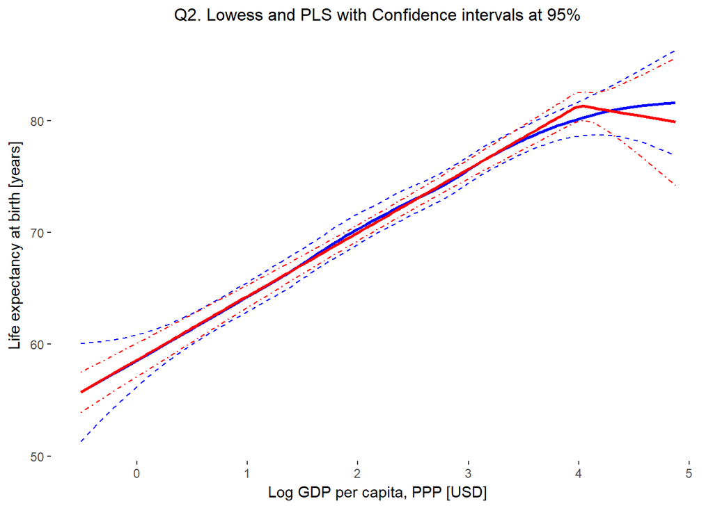

We would keep the linear (level - log) model or the following reasons: - In R square this is very close to the best models (which is PLS), the difference in very small, - The simple linear has a big advantage: its simplicity, - PLS shows some negative slope towards the high end oog Log GDP, something that we do not observe in the lowess.

For very similar reasons we prefer the linera level - log compared to some other models that have marginally better R-square, such as Quadratic Level -Log or Cubic Level - Log.

### 3. Estimate a weighted regression (weight=population). Compare results to what we saw in class.

In order to do it, first we need to enhance our data with population. For that we downloaded 2014 population data form the same “World Development Indicators” website.

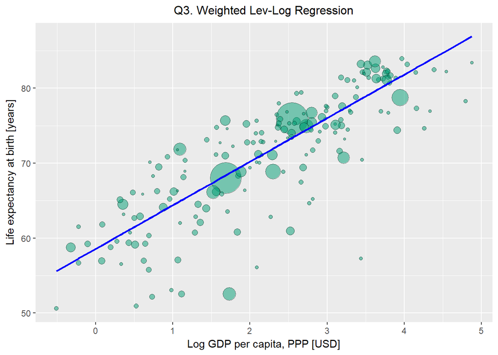

```
##
## Call:
## lm(formula = life ~ logGDP, data = Data2, weights = Population)
##
## Weighted Residuals:
##     Min      1Q  Median      3Q     Max
## -214125   -6833    1247    6878   95331
##
## Coefficients:
##             Estimate Std. Error t value Pr(>|t|)
## (Intercept)  58.5651     0.8004   73.17   <2e-16 ***
## logGDP        5.8169     0.3273   17.77   <2e-16 ***
## ---
## Signif. codes:  0 '***' 0.001 '**' 0.01 '*' 0.05 '.' 0.1 ' ' 1
##
## Residual standard error: 26160 on 177 degrees of freedom
## Multiple R-squared:  0.6408, Adjusted R-squared:  0.6388
## F-statistic: 315.8 on 1 and 177 DF,  p-value: < 2.2e-16
```

When doing a level-log regression without considering the population, the slope estimate was 5.46. It is now 5.82, slightly higher. China and India have the highest population in the world and they are very close to the regression line and are approximately in the middle of the log GDP per capita distribution, hence they don’t alter the slope significantly. We can say that after considering the population as weight, life expectancy is 0.582 years higher on average in countries with 10% higher GDP per capita.

## Problem 2.2

Download hotels_all_nov21.csv. Pick a city. Consider hotels and hostels. Consider all with at least 2 stars. You have 6 tasks (1p each). The goal of the exercise is to use information you have in your data to find a shortlist of five hotels and/or hostels that are good candidates for a good deal. You have to estimate a regression of prices (or log prices) on the other variables of your choice. You have to document your analysis and print the shortlist.

First we have loaded the file and picked a city randomly (happened to be Athens). We have filtered down the data to accommodation types ‘Hostel’ and ‘Hotel’ with at least 2 stars. After narrowing down the data we have done further data cleaning. We are interested in a few variables, such as distance from the city center, price, number of stars, rating, rating viewcounts, different badges of excellence the hotel or hostel might have, all other variables are excluded. First we have dropped 3 observations that miss parameters we might be interested in. Then we have dropped 2 duplicates, there were hotels with the same address, and a few hotels had more addresses, these have been sorted out.

Next step was to filter extreme values, a few hotels have been removed because being considered to be outside of Athens (apparently all those that are further away than the hotel with the highest distance in Piraeuswhich means that we conside everything that is further away then Piraeus as suburb not Athens). It is important to mention that we did not drop any hotel due to high price. We limited our investigation to hotels and hostels that are not futher than 5.9km.

### 2.2.1. Pick a set of variables. Describe all variables used in the analysis.

Now we need to describe all the variables we are going to use in the analysis.

First variable to discuss is price, currency is EUR and tells us, how much a single night costs for 2 people in that certain accommodation.

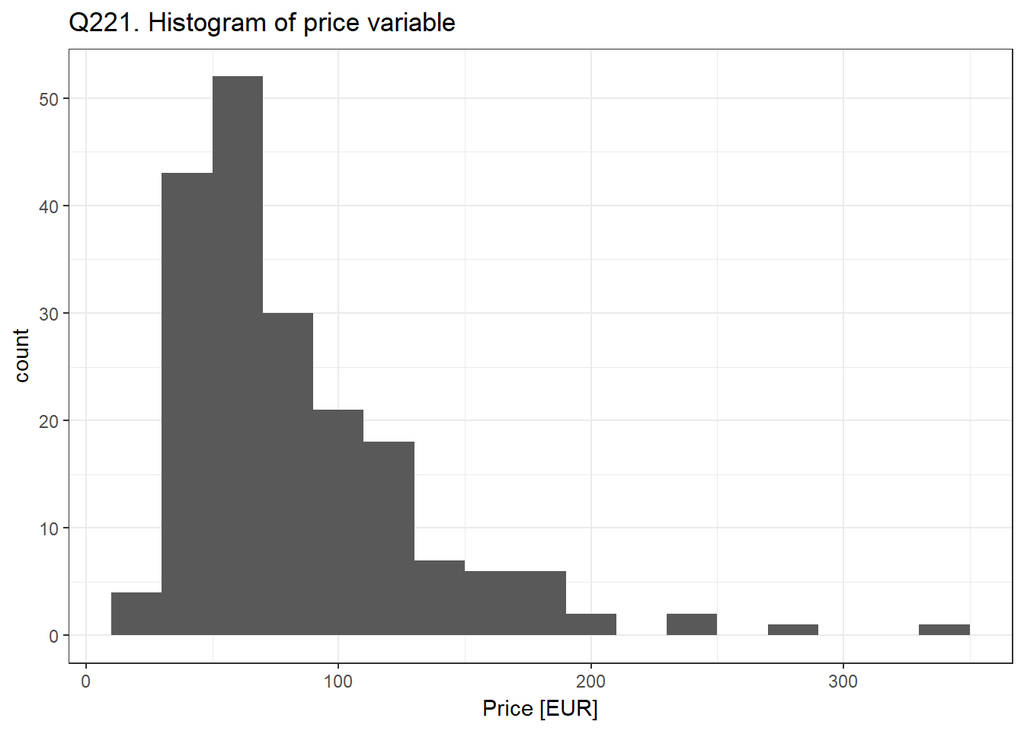

| mean_price | sd_price | min_price | max_price | p50 | p95 | n |
| --- | --- | --- | --- | --- | --- | --- |
| 83.03 | 47.86 | 23.22 | 336 | 68.49 | 177 | 193 |

Price variable has a log normal like distribution, it is skewed to the right with a long right tail. The mean is 83.0313472 EUR. The most offers are in the 50-70 price range. Price tells us, how much a single night costs for 2 people in that certain accommodation. We took the log of the price variable, please find a histogram of it below.

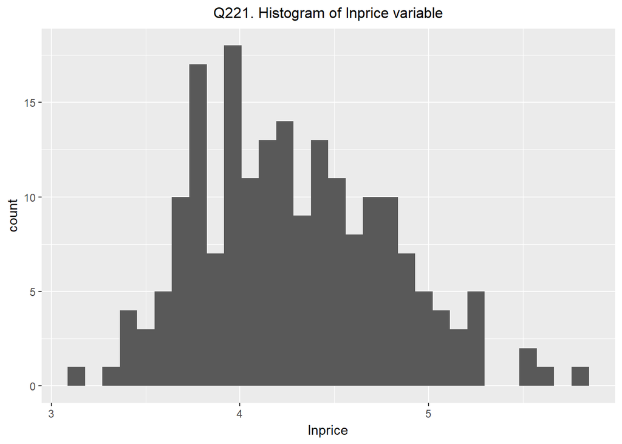

With having the logarithm of price variable we now have a more symmetric normal like distribution.

Distance variable describes how far a hotel or hostel is from the city center, it is measured in km.

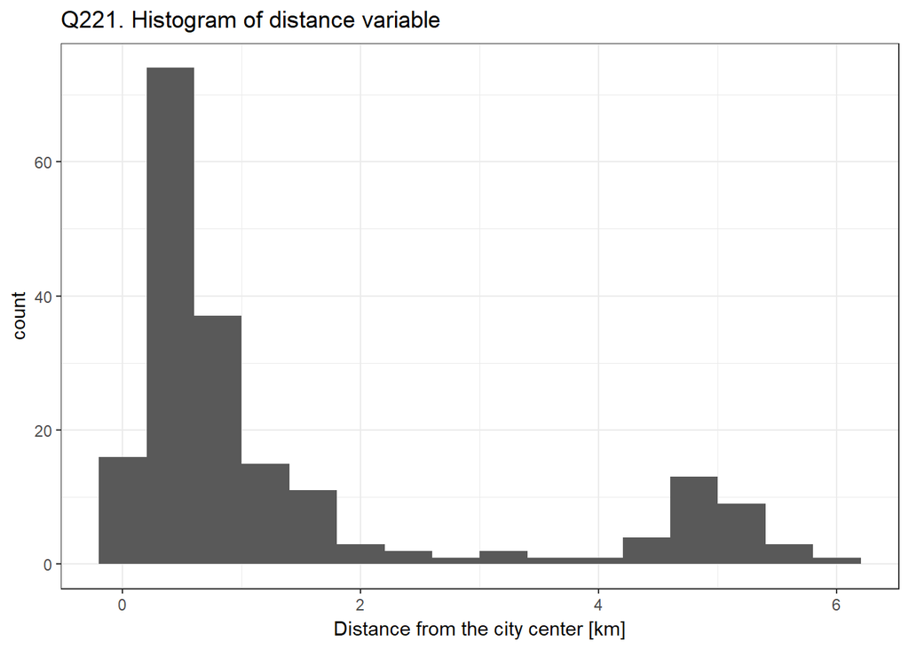

| mean_dist | sd_dist | min_dist | max_dist | p50 | p95 | n |
| --- | --- | --- | --- | --- | --- | --- |
| 1.477 | 1.662 | 0 | 5.9 | 0.7 | 5.24 | 193 |

After having these variables shortly described let’s create two scatterplots with distance on the x axis, price and lnprice on the y axis, to see, if there is any general relation to observe betweem tha variables.

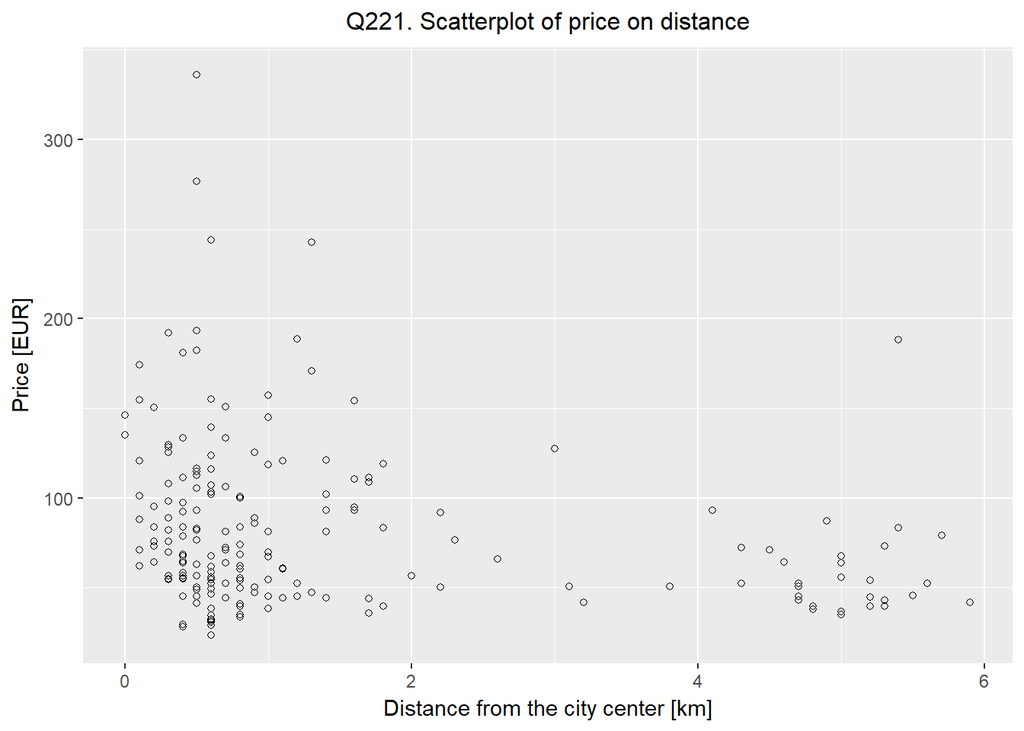

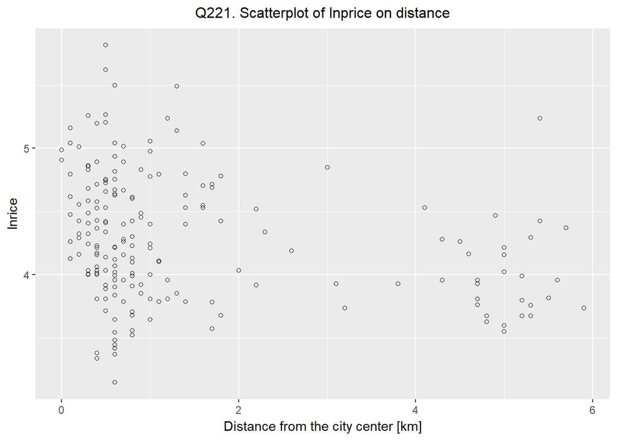

Both scatterplot shows that there is a general negative relation between price and distance closer to the city center, which might not be true for observations further from the center. We need to investigate it further.

Stars variable shows how many stars a hotel or hostel has. There are a few accommodations with half stars. 2 stars are the most common in our data, the more stars the accommodation has, the less observations we have in the data. Please find a histogram of stars below.

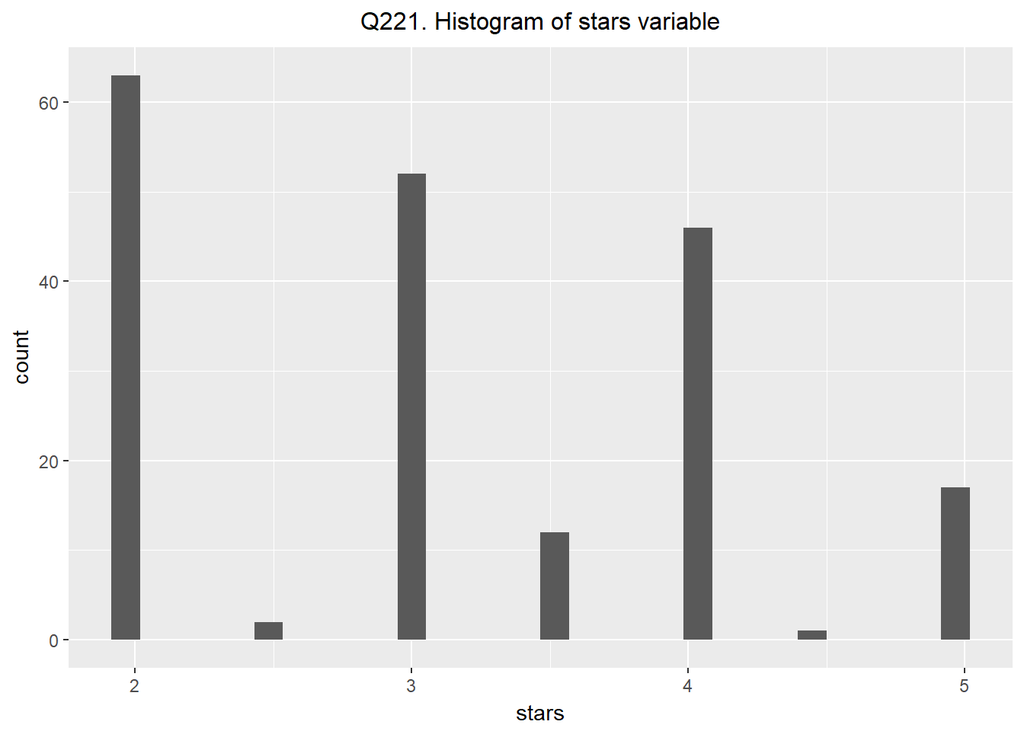

| 2 | 2.5 | 3 | 3.5 | 4 | 4.5 | 5 |
| --- | --- | --- | --- | --- | --- | --- |
| 63 | 2 | 52 | 12 | 46 | 1 | 17 |

We have created a histogram of the rating variable, please find some summary statistics below.

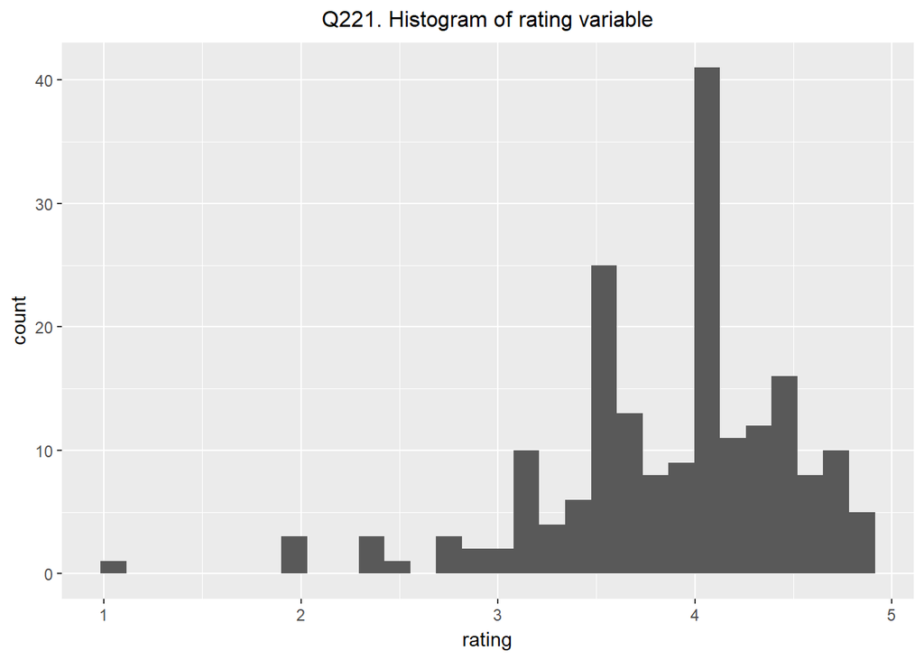

| mean_rating | sd_rating | min_rating | max_rating | p50 | p95 | n |
| --- | --- | --- | --- | --- | --- | --- |
| 3.869 | 0.6076 | 1 | 4.8 | 4 | 4.7 | 193 |

It has a range of 1 - 4.8, with one decimal. These ratings have been given by previous guests and should represent how satisfied they were with services provided. It is a numeric value and its distribution is skewed to the left, the mean is 3.8689119.

### 2.2.2. Investigate potential nonlinearity of each explanatory variable in simple regressions of the dependent variable. Decide on a parametric functional form for each.

We were investiagting potential non-linearity by using lowess non-parametric regression first. This regression is supposed to uncover potential non-linearities. At first let’s estimate a lowess regression on lnprice and distance.

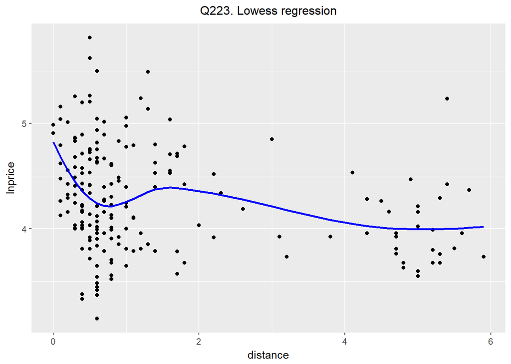

The lowess regression shows that there is a strong negative relation between price and distance very close to the city center, but at about 1km away from the center there is a change in the relation. At approximately 1.5km the relation becomes negative again, but it is much flatter now than in the first section, at the very end it becomes totally flat. It is important to highlight that there are only a few observation in the 2-4 km range.

Then let’s estimate a lowess regression on ln price and rating.

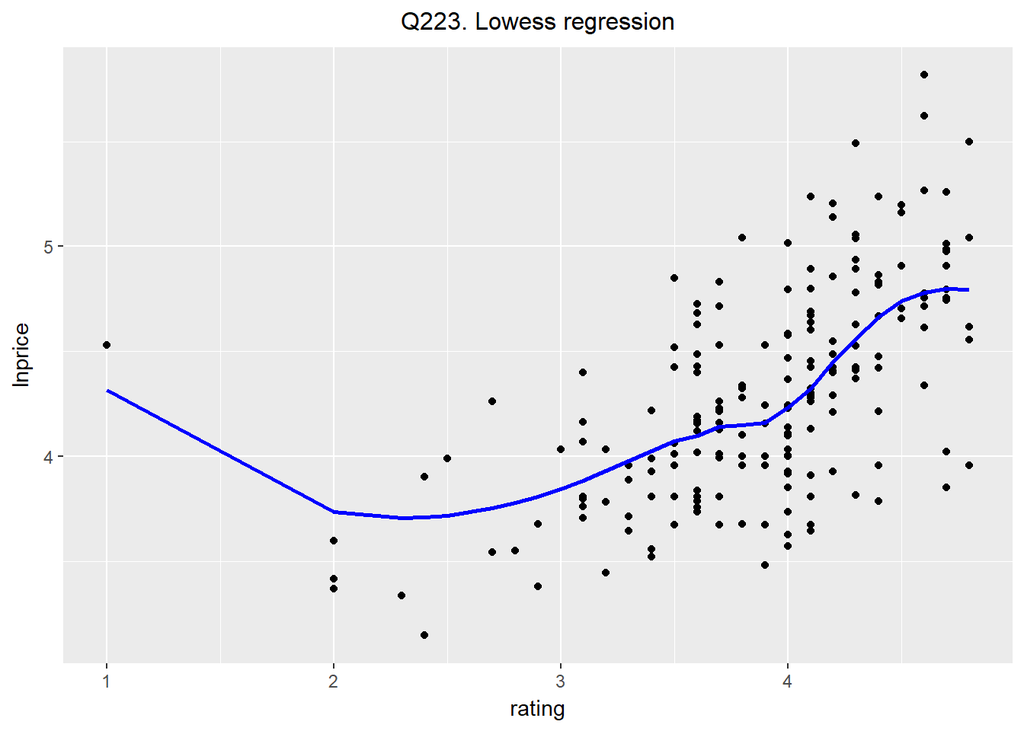

It shows the beyond rating 2 there is a general positive relation between lnprice and rating.

Below is a summary on the R squares of the various linear and non linear regressions. In the first table it is for price level, in the second one for log price.

| RegType | Distance | Stars | Gold | Loved | Top | Rating |
| --- | --- | --- | --- | --- | --- | --- |
| lev - lev lin | 0.0579 | 0.5265 | 0.0301 | 0.212 | 0.00876 | 0.2601 |
| lev - log | 0.05247 | 0.4746 | 0.0301 | 0.212 | 0.00876 | 0.1914 |
| Quadratic | 0.05966 | 0.5786 | 0.0301 | 0.212 | 0.00876 | 0.3444 |
| Qubic | 0.05991 | 0.5808 | 0.0301 | 0.212 | 0.00876 | 0.3446 |

| RegType | Distance | Stars | Gold | Loved | Top | Rating |
| --- | --- | --- | --- | --- | --- | --- |
| log - lev lin | 0.07107 | 0.5954 | 0.02298 | 0.1654 | 0.01497 | 0.3312 |
| log - log | 0.06792 | 0.5683 | 0.02298 | 0.1654 | 0.01497 | 0.2534 |
| Log Quadratic | 0.07217 | 0.6016 | 0.02298 | 0.1654 | 0.01497 | 0.3935 |
| Log Qubic | 0.07384 | 0.6016 | 0.02298 | 0.1654 | 0.01497 | 0.4003 |

As we saw in the price histogram, price is very much right skewed, we therefore analize log price. Based on R-square we select the following functional forms:

- Distance: Cubic, because of the price - distance lowess chart we saw (has local min and max too)
- Stars: Linear, as the realtive R-square gains of anz higher order polinom would not justify the extra complexity
- Gold dummy variable: due to its poor R-square we probably ignore it, but let us see later
- Loved dummy variable: we use the linear, as this is a binary so no point using any other
- Rating: Quadratic, because of the price - rating lowess chart we saw (close to parabola)

### 3. Estimate a multiple regression with all explanatory variables in the functional form you specified previously.

We consider the above parameters for multiple regression.

```
##
## Call:
## lm(formula = log(price) ~ distance + distance_2 + distance_3 +
##     stars + Top + Loved + rating + rating_2, data = myhotels3)
##
## Residuals:
##      Min       1Q   Median       3Q      Max
## -0.73448 -0.16935 -0.00647  0.15084  0.72659
##
## Coefficients:
##              Estimate Std. Error t value Pr(>|t|)
## (Intercept)  4.069020   0.394646  10.311  < 2e-16 ***
## distance    -0.135290   0.117492  -1.151  0.25103
## distance_2   0.040725   0.054342   0.749  0.45456
## distance_3  -0.003713   0.006815  -0.545  0.58652
## stars        0.325070   0.022977  14.147  < 2e-16 ***
## Top         -0.139666   0.164950  -0.847  0.39825
## Loved        0.059071   0.084500   0.699  0.48540
## rating      -0.750344   0.225056  -3.334  0.00104 **
## rating_2     0.142884   0.032763   4.361 2.15e-05 ***
## ---
## Signif. codes:  0 '***' 0.001 '**' 0.01 '*' 0.05 '.' 0.1 ' ' 1
##
## Residual standard error: 0.2692 on 184 degrees of freedom
## Multiple R-squared:  0.7272, Adjusted R-squared:  0.7154
## F-statistic: 61.33 on 8 and 184 DF,  p-value: < 2.2e-16
```

```
##
## Call:
## lm(formula = log(price) ~ distance + distance_2 + distance_3 +
##     stars + Gold + rating + rating_2, data = myhotels3)
##
## Residuals:
##      Min       1Q   Median       3Q      Max
## -0.73820 -0.16936 -0.00751  0.15353  0.71850
##
## Coefficients:
##              Estimate Std. Error t value Pr(>|t|)
## (Intercept)  4.096578   0.379081  10.807  < 2e-16 ***
## distance    -0.150890   0.115016  -1.312 0.191178
## distance_2   0.046758   0.053583   0.873 0.383996
## distance_3  -0.004356   0.006750  -0.645 0.519507
## stars        0.326539   0.022748  14.355  < 2e-16 ***
## Gold         0.001477   0.143714   0.010 0.991811
## rating      -0.773267   0.215112  -3.595 0.000416 ***
## rating_2     0.146727   0.030851   4.756 3.96e-06 ***
## ---
## Signif. codes:  0 '***' 0.001 '**' 0.01 '*' 0.05 '.' 0.1 ' ' 1
##
## Residual standard error: 0.2696 on 185 degrees of freedom
## Multiple R-squared:  0.725,  Adjusted R-squared:  0.7146
## F-statistic: 69.67 on 7 and 185 DF,  p-value: < 2.2e-16
```

R saquare seems to be fairly OK, much better compared to any simple regression of any shape.

Looking at the coefficients we can see that some add little and close to zero, so let us see what happens to R square if we drop those variables and simplify the model. We drop: distance_2, distance_3, Gold, Loved. For the rets, the multiple regression is re-calculated.

```
##
## Call:
## lm(formula = log(price) ~ distance + stars + Top + rating + rating_2,
##     data = myhotels3)
##
## Residuals:
##      Min       1Q   Median       3Q      Max
## -0.71965 -0.15250  0.00773  0.13788  0.72806
##
## Coefficients:
##             Estimate Std. Error t value Pr(>|t|)
## (Intercept)  4.11623    0.37347  11.022  < 2e-16 ***
## distance    -0.01757    0.01209  -1.454 0.147634
## stars        0.32201    0.02233  14.421  < 2e-16 ***
## Top         -0.15928    0.16101  -0.989 0.323819
## rating      -0.82159    0.21140  -3.886 0.000141 ***
## rating_2     0.15564    0.03009   5.173 5.89e-07 ***
## ---
## Signif. codes:  0 '***' 0.001 '**' 0.01 '*' 0.05 '.' 0.1 ' ' 1
##
## Residual standard error: 0.2688 on 187 degrees of freedom
## Multiple R-squared:  0.7237, Adjusted R-squared:  0.7163
## F-statistic: 97.94 on 5 and 187 DF,  p-value: < 2.2e-16
```

As we see it was a good simplification: we got rid of a few “complicated” variables while kept R-square almost as high as it was.

Doing the t-tests for each regression

[output not shown]

### 4. Pick two slope coefficients, interpret them, and compute and interpret their 95% CI.

We have picked the slope of log price on distance…

…and the slope of log price on rating

Interpretations.

price/distance:

95°% CI: 2.5 % 97.5 % (Intercept) 4.4687548 4.7370031 distance -0.3126862 -0.1065369

Negative correlation, slope estimated -0.21.The t(p) value is close to zero, indicating a significant relationship between price and distance. R squared is low, meaning that solely the var. distance is hardly explaining the variance of price

price/rating:

95°% CI 2.5 % 97.5 % (Intercept) 0.7255570 1.9311240 rating 0.6017687 0.8950387

Positive correlation, slope estimated +0.75.The t(p) value is close to zero here as well, indicating a significant relationship between price and rating. R squared is mutch higher then in price/distance regression (although still not high), the meaning is that the variance of rating gives a better explanation of the variance of price then we saw in case of price on distance. Lower Residual Standard Error of price/rating regression compared to price/ distance also confirming the stronger relation between variables, by showing a better fit of regression.

### 5. Describe your strategy to find the best deal.

The strategy to find the best deal is to find offers that have the largest negative residuals. The regression line tells us what would be the price on average. The greater the residual is in a negative sense, the better deal we find.

### 6. List the hotels with the smallest (most negative) residuals. List their prices and other characteristics as well. Comment on the results.

The 3 best deal hotels are in the below table.

```
##                                name distance stars badge_excellence rating
## 1:                      Lilia Hotel      4.8   3.5                     4.0
## 2: White Lotus Luxury Accommodation      0.8   4.0                     4.1
## 3:                    Faros 1 Hotel      5.3   3.0                     4.1
##    rating_reviewcount price  lnprice lndistance Gold Loved Top distance_2
## 1:                250 37.61 3.627270  1.5892352  0.1   0.1 0.1      23.04
## 2:                 85 49.77 3.907412 -0.1053605  0.1   0.1 0.1       0.64
## 3:                195 39.43 3.674527  1.6863990  0.1   0.1 0.1      28.09
##    distance_3 rating_2        res
## 1:    110.592    16.00 -0.7196506
## 2:      0.512    16.81 -0.7147226
## 3:    148.877    16.81 -0.5465139
```